# Lab Activity 2

Livio Finos

## 1 Multiple Linear Regression Homework: Model Selection via F-tests, Adjusted R², AIC, and Effect Sizes

**Objective**: Select and justify the best model for diabetes progression (using in-sample criteria only): F-tests, adjusted R², AIC/BIC, and standardized effect sizes.

### 1.1 Part 1: Data loading and exploration (10 points)

```r
library(tidyverse)
diab <- read_csv("./data/diabetes_sklearn.csv")
```

| Variable | Description | Units (pre-standardization) | Notes |
| --- | --- | --- | --- |
| age | Age | Years | - |
| sex | Sex | M/F coded quantitatively | Typically -0.0446 (female), +0.0507 (male) |
| bmi | Body mass index | kg/m² | Strongest univariate predictor |
| bp | Average blood pressure | mm Hg | - |
| s1 | Total serum cholesterol (tc) | mg/dL | - |
| s2 | Low-density lipoprotein (ldl) | mg/dL | “Bad” cholesterol |
| s3 | High-density lipoprotein (hdl) | mg/dL | “Good” cholesterol |
| s4 | Total cholesterol / HDL ratio (tch) | Ratio | Higher = worse risk profile |
| s5 | Log serum triglycerides (ltg) | log(mg/dL) | Often second-strongest predictor |
| s6 | Blood glucose level (glu) | mg/dL | Fasting blood sugar |
| target | Disease progression | Quantitative score | One year after baseline; mean=152, SD=77, range 25–346 |

**Tasks**:

1. Report predictor correlations with `target`, and pairwise correlations among top 3 predictors of `target`.
2. Scatterplot matrix of `target` vs `{bmi, s5, bp}`. Comment on linearity.

### 1.2 Part 2: Baseline models (20 points)

Fit these nested models:

```r
m_null  <- lm(target ~ 1, data = diab)                    # Intercept only
m_small <- lm(target ~ age + sex + bmi + bp, data = diab) # 4 clinical basics
m_full  <- lm(target ~ ., data = diab)                    # All 10 predictors
```

**Tasks**:

1. Compute and tabulate adjusted R² and AIC/BIC for all three.
2. **Global F-tests**: `anova(m_null, m_small)` and `anova(m_small, m_full)`. Interpret p-values: evidence against null model? Incremental value of extra 6 predictors?
3. **Effect size**: Report partial η² for each predictor in `m_full` (use `performance::model_performance()` or `car::Anova()`).

### 1.3 Part 3: Your model selection (20 points)

**Propose `m_yours`** (4–8 predictors). Justify based on:  
- Domain (e.g., BMI central to diabetes).  
- Univariate correlations.  
- Expected confounding (e.g., control for age/sex).

Example:

```r
m_yours <- lm(target ~ bmi + s5 + s6 + sex + age, data = diab)
```

**Tasks**:

1. Tabulate adjusted R², AIC/BIC vs `m_small` and `m_full`. Which “wins”?
2. **Hierarchical F-test**: `anova(m_yours, m_full)`. Significant loss in fit?
3. **Standardized effects**: Scale predictors and refit. Rank top 3 coefficients by magnitude (effect size).

### 1.4 Part 4: Model comparison table (15 points)

Create this table (using `broom::glance()` + `bind_rows()`):

| Model | adj.R² | Δadj.R² | AIC | ΔAIC | Global F (p) |
| --- | --- | --- | --- | --- | --- |
| m_null |  | - |  | - | - |
| m_small |  |  |  |  |  |
| m_yours |  |  |  |  |  |
| m_full |  |  |  |  |  |

**Discussion** (3–4 sentences): Best model by each criterion? Why AIC/BIC favor parsimony? Trade-off with adj.R²?

### 1.5 Part 5: Interpretation and effect sizes (20 points)

For your best model:

```r
library(car)
Anova(m_yours, type="III")  # Type III SS for effect sizes
```

```
## Anova Table (Type III tests)
##
## Response: target
##               Sum Sq  Df   F value  Pr(>F)
## (Intercept) 10229912   1 3184.9720 < 2e-16 ***
## bmi           322025   1  100.2590 < 2e-16 ***
## s5            235764   1   73.4024 < 2e-16 ***
## s6              8786   1    2.7356 0.09886 .
## sex             9482   1    2.9522 0.08647 .
## age               64   1    0.0199 0.88799
## Residuals    1400402 436
## ---
## Signif. codes:  0 '***' 0.001 '**' 0.01 '*' 0.05 '.' 0.1 ' ' 1
```

**Tasks**: 1. Identify 2 strongest predictors (Type III F or partial η² > 0.02).  
2. Interpret: “The effect of BMI is [X] units per SD, p=[Y].”  
3. **Discussion**: Confounding example? (Compare univariate vs multivariate coefficient for BMI.)

### 1.6 Part 6: Diagnostics (10 points)

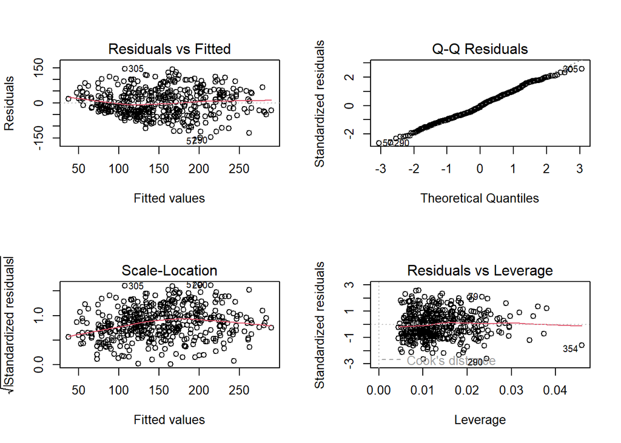

```r
par(mfrow=c(2,2)); plot(m_yours)
```

Comment briefly: violations? Influential cases?

### 1.7 Part 7: Peer review interaction (5 points)

**In class**: Share your table and best model. Groups vote: most parsimonious? Most explanatory? Submit 1-sentence peer feedback.

**Total: 100 points**.